# Ensemble Techniques Project

# Part A - 30 Marks

DOMAIN: Telecom

• CONTEXT: A telecom company wants to use their historical customer data to predict behaviour to retain customers.

```
You can analyse all relevant customer data and develop focused customer retention programs.
```

• DATA DESCRIPTION: Each row represents a customer, each column contains customer’s attributes described on the column Metadata. The data set includes information about:

• Customers who left within the last month – the column is called Churn

• Services that each customer has signed up for – phone, multiple lines, internet, online security, online backup, device protection, tech support, and streaming TV and movies

• Customer account information – how long they’ve been a customer, contract, payment method, paperless billing, monthly charges, and total charges

• Demographic info about customers – gender, age range, and if they have partners and dependents

PROJECT OBJECTIVE:

To Build a model that will help to identify the potential customers who have a higher probability to churn. This helps the company to understand the pinpoints and patterns of customer churn and will increase the focus on strategizing customer retention.

# STEPS AND TASK [30 Marks]:

```python
# import libraries

%matplotlib inline
# all the basic libraries that we need
import numpy as np
import pandas as pd
import matplotlib.pyplot as plt
import seaborn as sns
sns.set_style(style= 'darkgrid')

# pre-processing method
from sklearn.model_selection import train_test_split

# the regression models
from sklearn.linear_model import LinearRegression
from sklearn.tree import DecisionTreeRegressor
from sklearn.ensemble import BaggingRegressor
from sklearn.ensemble import RandomForestRegressor
from sklearn.ensemble import GradientBoostingRegressor
from xgboost import XGBRegressor
from catboost import CatBoostRegressor
from lightgbm import LGBMRegressor

# methods and classes for evaluation
from sklearn import metrics
from math import sqrt
from sklearn.model_selection import cross_validate
import time
```

# 1. Data Understanding & Exploration: [5 Marks]

```python
# 1A. Read ‘TelcomCustomer-Churn_1.csv’ as a DataFrame and assign it to a variable. [1 Mark]

df1= pd.read_csv("TelcomCustomer-Churn_1.csv")
df1.head()
```

|  | customerID | gender | SeniorCitizen | Partner | Dependents | tenure | PhoneService | MultipleLines | InternetService | OnlineSecurity |
| --- | --- | --- | --- | --- | --- | --- | --- | --- | --- | --- |
| 0 | 7590-VHVEG | Female | 0 | Yes | No | 1 | No | No phone service | DSL | No |
| 1 | 5575-GNVDE | Male | 0 | No | No | 34 | Yes | No | DSL | Yes |
| 2 | 3668-QPYBK | Male | 0 | No | No | 2 | Yes | No | DSL | Yes |
| 3 | 7795-CFOCW | Male | 0 | No | No | 45 | No | No phone service | DSL | Yes |
| 4 | 9237-HQITU | Female | 0 | No | No | 2 | Yes | No | Fiber optic | No |

```python
# 1B. Read ‘TelcomCustomer-Churn_2.csv’ as a DataFrame and assign it to a variable. [1 Mark]

df2= pd.read_csv("TelcomCustomer-Churn_2.csv")
df2.head()
```

|  | customerID | OnlineBackup | DeviceProtection | TechSupport | StreamingTV | StreamingMovies | Contract | PaperlessBilling | PaymentMethod | MonthlyCharges | TotalCharges | Churn |
| --- | --- | --- | --- | --- | --- | --- | --- | --- | --- | --- | --- | --- |
| 0 | 7590-VHVEG | Yes | No | No | No | No | Month-to-month | Yes | Electronic check | 29.85 | 29.85 | No |
| 1 | 5575-GNVDE | No | Yes | No | No | No | One year | No | Mailed check | 56.95 | 1889.5 | No |
| 2 | 3668-QPYBK | Yes | No | No | No | No | Month-to-month | Yes | Mailed check | 53.85 | 108.15 | Yes |
| 3 | 7795-CFOCW | No | Yes | Yes | No | No | One year | No | Bank transfer (automatic) | 42.30 | 1840.75 | No |
| 4 | 9237-HQITU | No | No | No | No | No | Month-to-month | Yes | Electronic check | 70.70 | 151.65 | Yes |

```python
print('Shape of first Dataframe:  ',df1.shape)
print('\nColumns of second Dataframe: \n',df1.columns)
print('\nColumn Datatypes of First Dataframe: \n',df1.dtypes)


print('Shape of second Dataframe: ',df2.shape)
print('\nColumns of First Dataframe: \n',df2.columns)
print('\nColumn Datatypes of second Dataframe: \n',df2.dtypes)
```

```
Shape of first Dataframe:   (7043, 10)

Columns of second Dataframe:
 Index(['customerID', 'gender', 'SeniorCitizen', 'Partner', 'Dependents',
       'tenure', 'PhoneService', 'MultipleLines', 'InternetService',
       'OnlineSecurity'],
      dtype='object')

Column Datatypes of First Dataframe:
 customerID         object
gender             object
SeniorCitizen       int64
Partner            object
Dependents         object
tenure              int64
PhoneService       object
MultipleLines      object
InternetService    object
OnlineSecurity     object
dtype: object
Shape of second Dataframe:  (7043, 12)

Columns of First Dataframe:
 Index(['customerID', 'OnlineBackup', 'DeviceProtection', 'TechSupport',
       'StreamingTV', 'StreamingMovies', 'Contract', 'PaperlessBilling',
       'PaymentMethod', 'MonthlyCharges', 'TotalCharges', 'Churn'],
      dtype='object')

Column Datatypes of second Dataframe:
 customerID           object
OnlineBackup         object
DeviceProtection     object
TechSupport          object
StreamingTV          object
StreamingMovies      object
Contract             object
PaperlessBilling     object
PaymentMethod        object
MonthlyCharges      float64
TotalCharges         object
Churn                object
dtype: object
```

```python
# 1C. Merge both the DataFrames on key ‘customerID’ to form a single DataFrame [2 Mark]

df_merged = df1.merge(df2, on='customerID')
print('After merging: ')
print('Shape of merged dataset: ',df_merged.shape)
df_merged.head()
```

```
After merging:
Shape of merged dataset:  (7043, 21)
```

|  | customerID | gender | SeniorCitizen | Partner | Dependents | tenure | PhoneService | MultipleLines | InternetService | OnlineSecurity | ... | DeviceProtection | TechSupport | StreamingTV | StreamingMovies | Contract | PaperlessBilling | PaymentMethod | MonthlyCharges | TotalCharges | Churn |
| --- | --- | --- | --- | --- | --- | --- | --- | --- | --- | --- | --- | --- | --- | --- | --- | --- | --- | --- | --- | --- | --- |
| 0 | 7590-VHVEG | Female | 0 | Yes | No | 1 | No | No phone service | DSL | No | ... | No | No | No | No | Month-to-month | Yes | Electronic check | 29.85 | 29.85 | No |
| 1 | 5575-GNVDE | Male | 0 | No | No | 34 | Yes | No | DSL | Yes | ... | Yes | No | No | No | One year | No | Mailed check | 56.95 | 1889.5 | No |
| 2 | 3668-QPYBK | Male | 0 | No | No | 2 | Yes | No | DSL | Yes | ... | No | No | No | No | Month-to-month | Yes | Mailed check | 53.85 | 108.15 | Yes |
| 3 | 7795-CFOCW | Male | 0 | No | No | 45 | No | No phone service | DSL | Yes | ... | Yes | Yes | No | No | One year | No | Bank transfer (automatic) | 42.30 | 1840.75 | No |
| 4 | 9237-HQITU | Female | 0 | No | No | 2 | Yes | No | Fiber optic | No | ... | No | No | No | No | Month-to-month | Yes | Electronic check | 70.70 | 151.65 | Yes |

5 rows × 21 columns

```python
# 1D. Verify if all the columns are incorporated in the merged DataFrame by using simple comparison Operator in Python. [1 Marks]

pd.merge(df1,df2).equals(df_merged)
```

```
True
```

# 2. Data Cleaning & Analysis: [5 Marks]

```python
# 2A. Impute missing/unexpected values in the DataFrame. [2 Marks]
df_merged.dtypes
```

```
customerID           object
gender               object
SeniorCitizen         int64
Partner              object
Dependents           object
tenure                int64
PhoneService         object
MultipleLines        object
InternetService      object
OnlineSecurity       object
OnlineBackup         object
DeviceProtection     object
TechSupport          object
StreamingTV          object
StreamingMovies      object
Contract             object
PaperlessBilling     object
PaymentMethod        object
MonthlyCharges      float64
TotalCharges         object
Churn                object
dtype: object
```

```python
df_merged.head()
```

|  | customerID | gender | SeniorCitizen | Partner | Dependents | tenure | PhoneService | MultipleLines | InternetService | OnlineSecurity | ... | DeviceProtection | TechSupport | StreamingTV | StreamingMovies | Contract | PaperlessBilling | PaymentMethod | MonthlyCharges | TotalCharges | Churn |
| --- | --- | --- | --- | --- | --- | --- | --- | --- | --- | --- | --- | --- | --- | --- | --- | --- | --- | --- | --- | --- | --- |
| 0 | 7590-VHVEG | Female | 0 | Yes | No | 1 | No | No phone service | DSL | No | ... | No | No | No | No | Month-to-month | Yes | Electronic check | 29.85 | 29.85 | No |
| 1 | 5575-GNVDE | Male | 0 | No | No | 34 | Yes | No | DSL | Yes | ... | Yes | No | No | No | One year | No | Mailed check | 56.95 | 1889.5 | No |
| 2 | 3668-QPYBK | Male | 0 | No | No | 2 | Yes | No | DSL | Yes | ... | No | No | No | No | Month-to-month | Yes | Mailed check | 53.85 | 108.15 | Yes |
| 3 | 7795-CFOCW | Male | 0 | No | No | 45 | No | No phone service | DSL | Yes | ... | Yes | Yes | No | No | One year | No | Bank transfer (automatic) | 42.30 | 1840.75 | No |
| 4 | 9237-HQITU | Female | 0 | No | No | 2 | Yes | No | Fiber optic | No | ... | No | No | No | No | Month-to-month | Yes | Electronic check | 70.70 | 151.65 | Yes |

5 rows × 21 columns

```python
df_merged.describe(include='all').T
```

|  | count | unique | top | freq | mean | std | min | 25% | 50% | 75% | max |
| --- | --- | --- | --- | --- | --- | --- | --- | --- | --- | --- | --- |
| customerID | 7043 | 7043 | 7590-VHVEG | 1 | NaN | NaN | NaN | NaN | NaN | NaN | NaN |
| gender | 7043 | 2 | Male | 3555 | NaN | NaN | NaN | NaN | NaN | NaN | NaN |
| SeniorCitizen | 7043.0 | NaN | NaN | NaN | 0.162147 | 0.368612 | 0.0 | 0.0 | 0.0 | 0.0 | 1.0 |
| Partner | 7043 | 2 | No | 3641 | NaN | NaN | NaN | NaN | NaN | NaN | NaN |
| Dependents | 7043 | 2 | No | 4933 | NaN | NaN | NaN | NaN | NaN | NaN | NaN |
| tenure | 7043.0 | NaN | NaN | NaN | 32.371149 | 24.559481 | 0.0 | 9.0 | 29.0 | 55.0 | 72.0 |
| PhoneService | 7043 | 2 | Yes | 6361 | NaN | NaN | NaN | NaN | NaN | NaN | NaN |
| MultipleLines | 7043 | 3 | No | 3390 | NaN | NaN | NaN | NaN | NaN | NaN | NaN |
| InternetService | 7043 | 3 | Fiber optic | 3096 | NaN | NaN | NaN | NaN | NaN | NaN | NaN |
| OnlineSecurity | 7043 | 3 | No | 3498 | NaN | NaN | NaN | NaN | NaN | NaN | NaN |
| OnlineBackup | 7043 | 3 | No | 3088 | NaN | NaN | NaN | NaN | NaN | NaN | NaN |
| DeviceProtection | 7043 | 3 | No | 3095 | NaN | NaN | NaN | NaN | NaN | NaN | NaN |
| TechSupport | 7043 | 3 | No | 3473 | NaN | NaN | NaN | NaN | NaN | NaN | NaN |
| StreamingTV | 7043 | 3 | No | 2810 | NaN | NaN | NaN | NaN | NaN | NaN | NaN |
| StreamingMovies | 7043 | 3 | No | 2785 | NaN | NaN | NaN | NaN | NaN | NaN | NaN |
| Contract | 7043 | 3 | Month-to-month | 3875 | NaN | NaN | NaN | NaN | NaN | NaN | NaN |
| PaperlessBilling | 7043 | 2 | Yes | 4171 | NaN | NaN | NaN | NaN | NaN | NaN | NaN |
| PaymentMethod | 7043 | 4 | Electronic check | 2365 | NaN | NaN | NaN | NaN | NaN | NaN | NaN |
| MonthlyCharges | 7043.0 | NaN | NaN | NaN | 64.761692 | 30.090047 | 18.25 | 35.5 | 70.35 | 89.85 | 118.75 |
| TotalCharges | 7043 | 6531 |  | 11 | NaN | NaN | NaN | NaN | NaN | NaN | NaN |
| Churn | 7043 | 2 | No | 5174 | NaN | NaN | NaN | NaN | NaN | NaN | NaN |

Observation:

```python
# 2B. Make sure all the variables with continuous values are of ‘Float’ type. [2 Marks]
#     [For Example: MonthlyCharges, TotalCharges]

#df_merged['TotalCharges']= df_merged['TotalCharges'].astype(float)

# Column TotalCharges have some special characters hence we need to handle the special character data's
```

```python
df_merged[df_merged['TotalCharges'].str.count(' ') == 1]
```

|  | customerID | gender | SeniorCitizen | Partner | Dependents | tenure | PhoneService | MultipleLines | InternetService | OnlineSecurity | ... | DeviceProtection | TechSupport | StreamingTV | StreamingMovies | Contract | PaperlessBilling | PaymentMethod | MonthlyCharges | TotalCharges | Churn |
| --- | --- | --- | --- | --- | --- | --- | --- | --- | --- | --- | --- | --- | --- | --- | --- | --- | --- | --- | --- | --- | --- |
| 488 | 4472-LVYGI | Female | 0 | Yes | Yes | 0 | No | No phone service | DSL | Yes | ... | Yes | Yes | Yes | No | Two year | Yes | Bank transfer (automatic) | 52.55 |  | No |
| 753 | 3115-CZMZD | Male | 0 | No | Yes | 0 | Yes | No | No | No internet service | ... | No internet service | No internet service | No internet service | No internet service | Two year | No | Mailed check | 20.25 |  | No |
| 936 | 5709-LVOEQ | Female | 0 | Yes | Yes | 0 | Yes | No | DSL | Yes | ... | Yes | No | Yes | Yes | Two year | No | Mailed check | 80.85 |  | No |
| 1082 | 4367-NUYAO | Male | 0 | Yes | Yes | 0 | Yes | Yes | No | No internet service | ... | No internet service | No internet service | No internet service | No internet service | Two year | No | Mailed check | 25.75 |  | No |
| 1340 | 1371-DWPAZ | Female | 0 | Yes | Yes | 0 | No | No phone service | DSL | Yes | ... | Yes | Yes | Yes | No | Two year | No | Credit card (automatic) | 56.05 |  | No |
| 3331 | 7644-OMVMY | Male | 0 | Yes | Yes | 0 | Yes | No | No | No internet service | ... | No internet service | No internet service | No internet service | No internet service | Two year | No | Mailed check | 19.85 |  | No |
| 3826 | 3213-VVOLG | Male | 0 | Yes | Yes | 0 | Yes | Yes | No | No internet service | ... | No internet service | No internet service | No internet service | No internet service | Two year | No | Mailed check | 25.35 |  | No |
| 4380 | 2520-SGTTA | Female | 0 | Yes | Yes | 0 | Yes | No | No | No internet service | ... | No internet service | No internet service | No internet service | No internet service | Two year | No | Mailed check | 20.00 |  | No |
| 5218 | 2923-ARZLG | Male | 0 | Yes | Yes | 0 | Yes | No | No | No internet service | ... | No internet service | No internet service | No internet service | No internet service | One year | Yes | Mailed check | 19.70 |  | No |
| 6670 | 4075-WKNIU | Female | 0 | Yes | Yes | 0 | Yes | Yes | DSL | No | ... | Yes | Yes | Yes | No | Two year | No | Mailed check | 73.35 |  | No |
| 6754 | 2775-SEFEE | Male | 0 | No | Yes | 0 | Yes | Yes | DSL | Yes | ... | No | Yes | No | No | Two year | Yes | Bank transfer (automatic) | 61.90 |  | No |

11 rows × 21 columns

```python
#Replacing the special character data to zero
df_merged['TotalCharges'] = df_merged['TotalCharges'].str.replace(' ','0')
```

```python
df_merged[df_merged['TotalCharges'].str.count(' ') == 1]
```

|  | customerID | gender | SeniorCitizen | Partner | Dependents | tenure | PhoneService | MultipleLines | InternetService | OnlineSecurity | ... | DeviceProtection | TechSupport | StreamingTV | StreamingMovies | Contract | PaperlessBilling | PaymentMethod | MonthlyCharges | TotalCharges | Churn |
| --- | --- | --- | --- | --- | --- | --- | --- | --- | --- | --- | --- | --- | --- | --- | --- | --- | --- | --- | --- | --- | --- |

0 rows × 21 columns

```python
# Converting TotalCharges to Float
df_merged['TotalCharges']= df_merged['TotalCharges'].astype(float)

#Converting SeniorCitizen to Object
df_merged['SeniorCitizen']= df_merged['SeniorCitizen'].astype(object)
df_merged.dtypes
```

```
customerID           object
gender               object
SeniorCitizen        object
Partner              object
Dependents           object
tenure                int64
PhoneService         object
MultipleLines        object
InternetService      object
OnlineSecurity       object
OnlineBackup         object
DeviceProtection     object
TechSupport          object
StreamingTV          object
StreamingMovies      object
Contract             object
PaperlessBilling     object
PaymentMethod        object
MonthlyCharges      float64
TotalCharges        float64
Churn                object
dtype: object
```

```python
# 2C. Create a function that will accept a DataFrame as input and return pie-charts for all the appropriate Categorical
#     features. Clearly show percentage distribution in the pie-chart. [4 Marks]

#Function to plot Pie-Charts for all categorical variables in the dataframe
def pie_charts_for_CategoricalVar(df_pie,m):
    '''Takes in a dataframe(df_pie) and plots pie charts for all categorical columns. m = number of columns required in grid'''

    #get all the column names in the dataframe
    a = []
    for i in df_pie:
        a.append(i)

    #isolate the categorical variable names from a to b
    b = []
    for i in a:
        if (df_pie[i].dtype.name) == 'object':
            b.append(i)

    plt.figure(figsize=(15, 12))
    plt.subplots_adjust(hspace=0.2)
    plt.suptitle("Pie-Charts for Categorical Variables in the dataframe", fontsize=18, y=0.95)

    # number of columns, as inputted while calling the function
    ncols = m
    # calculate number of rows
    nrows = len(b) // ncols + (len(b) % ncols > 0)

    # loop through the length of 'b' and keep track of index
    for n, i in enumerate(b):
        # add a new subplot iteratively using nrows and ncols
        ax = plt.subplot(nrows, ncols, n + 1)

        # filter df and plot 'i' on the new subplot axis
        df_pie.groupby(i).size().plot(kind='pie', autopct='%.2f%%',ax=ax)

        ax.set_title(i.upper())
        ax.set_xlabel("")
        ax.set_ylabel("")
    plt.show()
```

```python
#calling the function to plot pie-charts for categorical variable

#Dropping customer id as its not required to be reported as categorical column
df_merged=df_merged.drop(["customerID"], axis=1)
```

```python
df_merged.columns
```

```
Index(['gender', 'SeniorCitizen', 'Partner', 'Dependents', 'tenure',
       'PhoneService', 'MultipleLines', 'InternetService', 'OnlineSecurity',
       'OnlineBackup', 'DeviceProtection', 'TechSupport', 'StreamingTV',
       'StreamingMovies', 'Contract', 'PaperlessBilling', 'PaymentMethod',
       'MonthlyCharges', 'TotalCharges', 'Churn'],
      dtype='object')
```

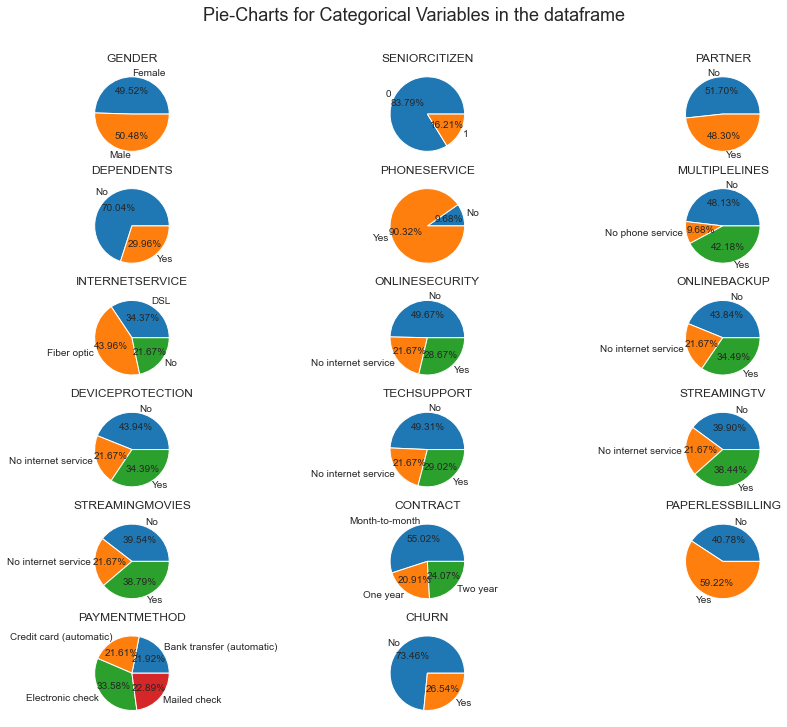

```python
pie_charts_for_CategoricalVar(df_merged,3)   #dataframe, no. of cols in the grid
```

```python
# 2D. Share insights for Q2.c. [2 Marks]

# There are almost equal number of male and female customers(50:50)
# In which only 16% are senior citizens
# Around 90% of people have raised for PhoneService
# Could see around 22% of customers has raised 'No internet Service'
# Overall, 27% of the customers are churned out based on the data.
```

```python
# 2E. Encode all the appropriate Categorical features with the best suitable approach. [2 Marks]

df_merged_onehotX = pd.get_dummies(df_merged, drop_first=True)
df_merged_onehotX.shape
```

```
(7043, 31)
```

```python
df_merged_onehotX.head()
```

|  | tenure | MonthlyCharges | TotalCharges | gender_Male | SeniorCitizen_1 | Partner_Yes | Dependents_Yes | PhoneService_Yes | MultipleLines_No phone service | MultipleLines_Yes | ... | StreamingTV_Yes | StreamingMovies_No internet service | StreamingMovies_Yes | Contract_One year | Contract_Two year | PaperlessBilling_Yes | PaymentMethod_Credit card (automatic) | PaymentMethod_Electronic check | PaymentMethod_Mailed check | Churn_Yes |
| --- | --- | --- | --- | --- | --- | --- | --- | --- | --- | --- | --- | --- | --- | --- | --- | --- | --- | --- | --- | --- | --- |
| 0 | 1 | 29.85 | 29.85 | 0 | 0 | 1 | 0 | 0 | 1 | 0 | ... | 0 | 0 | 0 | 0 | 0 | 1 | 0 | 1 | 0 | 0 |
| 1 | 34 | 56.95 | 1889.50 | 1 | 0 | 0 | 0 | 1 | 0 | 0 | ... | 0 | 0 | 0 | 1 | 0 | 0 | 0 | 0 | 1 | 0 |
| 2 | 2 | 53.85 | 108.15 | 1 | 0 | 0 | 0 | 1 | 0 | 0 | ... | 0 | 0 | 0 | 0 | 0 | 1 | 0 | 0 | 1 | 1 |
| 3 | 45 | 42.30 | 1840.75 | 1 | 0 | 0 | 0 | 0 | 1 | 0 | ... | 0 | 0 | 0 | 1 | 0 | 0 | 0 | 0 | 0 | 0 |
| 4 | 2 | 70.70 | 151.65 | 0 | 0 | 0 | 0 | 1 | 0 | 0 | ... | 0 | 0 | 0 | 0 | 0 | 1 | 0 | 1 | 0 | 1 |

5 rows × 31 columns

```python
df_merged_onehotX.dtypes
```

```
tenure                                     int64
MonthlyCharges                           float64
TotalCharges                             float64
gender_Male                                uint8
SeniorCitizen_1                            uint8
Partner_Yes                                uint8
Dependents_Yes                             uint8
PhoneService_Yes                           uint8
MultipleLines_No phone service             uint8
MultipleLines_Yes                          uint8
InternetService_Fiber optic                uint8
InternetService_No                         uint8
OnlineSecurity_No internet service         uint8
OnlineSecurity_Yes                         uint8
OnlineBackup_No internet service           uint8
OnlineBackup_Yes                           uint8
DeviceProtection_No internet service       uint8
DeviceProtection_Yes                       uint8
TechSupport_No internet service            uint8
TechSupport_Yes                            uint8
StreamingTV_No internet service            uint8
StreamingTV_Yes                            uint8
StreamingMovies_No internet service        uint8
StreamingMovies_Yes                        uint8
Contract_One year                          uint8
Contract_Two year                          uint8
PaperlessBilling_Yes                       uint8
PaymentMethod_Credit card (automatic)      uint8
PaymentMethod_Electronic check             uint8
PaymentMethod_Mailed check                 uint8
Churn_Yes                                  uint8
dtype: object
```

```python
# 2F. Split the data into 80% train and 20% test. [1 Marks]

# Let Y be the target and X be the features

target = df_merged_onehotX["Churn_Yes"]
features = df_merged_onehotX.drop(["Churn_Yes"], axis=1)

print(target.shape)
print(features.shape)
```

```
(7043,)
(7043, 30)
```

```python
from sklearn.model_selection import train_test_split

X_train, X_test, y_train, y_test = train_test_split(features,target, test_size = 0.2, random_state = 4)

print('shape of Train data test: ',X_train.shape)
print('shape of Test data test: ',X_test.shape)
```

```
shape of Train data test:  (5634, 30)
shape of Test data test:  (1409, 30)
```

```python
# 2G. Normalize/Standardize the data with the best suitable approach. [2 Marks]

from scipy.stats import zscore

X_Train_Scaled  = X_train.apply(zscore)  # convert all attributes to Z scale

X_Train_Scaled.describe().T
```

|  | count | mean | std | min | 25% | 50% | 75% | max |
| --- | --- | --- | --- | --- | --- | --- | --- | --- |
| tenure | 5634.0 | 4.618540e-17 | 1.000089 | -1.316384 | -0.948943 | -0.132408 | 0.929088 | 1.623143 |
| MonthlyCharges | 5634.0 | -3.527136e-16 | 1.000089 | -1.540232 | -0.971242 | 0.186645 | 0.835261 | 1.794085 |
| TotalCharges | 5634.0 | 4.244623e-17 | 1.000089 | -1.003851 | -0.827271 | -0.387681 | 0.652611 | 2.844008 |
| gender_Male | 5634.0 | 4.603268e-16 | 1.000089 | -1.007483 | -1.007483 | 0.992573 | 0.992573 | 0.992573 |
| SeniorCitizen_1 | 5634.0 | 1.376034e-15 | 1.000089 | -0.440337 | -0.440337 | -0.440337 | -0.440337 | 2.270986 |
| Partner_Yes | 5634.0 | 4.129935e-16 | 1.000089 | -0.961343 | -0.961343 | -0.961343 | 1.040211 | 1.040211 |
| Dependents_Yes | 5634.0 | 1.339992e-16 | 1.000089 | -0.651833 | -0.651833 | -0.651833 | 1.534135 | 1.534135 |
| PhoneService_Yes | 5634.0 | -4.652926e-16 | 1.000089 | -3.103255 | 0.322242 | 0.322242 | 0.322242 | 0.322242 |
| MultipleLines_No phone service | 5634.0 | 5.657132e-16 | 1.000089 | -0.322242 | -0.322242 | -0.322242 | -0.322242 | 3.103255 |
| MultipleLines_Yes | 5634.0 | -1.291516e-16 | 1.000089 | -0.855224 | -0.855224 | -0.855224 | 1.169285 | 1.169285 |
| InternetService_Fiber optic | 5634.0 | -4.388475e-16 | 1.000089 | -0.884185 | -0.884185 | -0.884185 | 1.130985 | 1.130985 |
| InternetService_No | 5634.0 | -9.188800e-17 | 1.000089 | -0.529305 | -0.529305 | -0.529305 | -0.529305 | 1.889271 |
| OnlineSecurity_No internet service | 5634.0 | -9.188800e-17 | 1.000089 | -0.529305 | -0.529305 | -0.529305 | -0.529305 | 1.889271 |
| OnlineSecurity_Yes | 5634.0 | -7.457451e-16 | 1.000089 | -0.629510 | -0.629510 | -0.629510 | 1.588538 | 1.588538 |
| OnlineBackup_No internet service | 5634.0 | -9.188800e-17 | 1.000089 | -0.529305 | -0.529305 | -0.529305 | -0.529305 | 1.889271 |
| OnlineBackup_Yes | 5634.0 | 8.609056e-16 | 1.000089 | -0.721559 | -0.721559 | -0.721559 | 1.385888 | 1.385888 |
| DeviceProtection_No internet service | 5634.0 | -9.188800e-17 | 1.000089 | -0.529305 | -0.529305 | -0.529305 | -0.529305 | 1.889271 |
| DeviceProtection_Yes | 5634.0 | 1.548479e-16 | 1.000089 | -0.726685 | -0.726685 | -0.726685 | 1.376111 | 1.376111 |
| TechSupport_No internet service | 5634.0 | -9.188800e-17 | 1.000089 | -0.529305 | -0.529305 | -0.529305 | -0.529305 | 1.889271 |
| TechSupport_Yes | 5634.0 | -1.329351e-16 | 1.000089 | -0.638589 | -0.638589 | -0.638589 | 1.565952 | 1.565952 |
| StreamingTV_No internet service | 5634.0 | -9.188800e-17 | 1.000089 | -0.529305 | -0.529305 | -0.529305 | -0.529305 | 1.889271 |
| StreamingTV_Yes | 5634.0 | -3.023653e-16 | 1.000089 | -0.784380 | -0.784380 | -0.784380 | 1.274892 | 1.274892 |
| StreamingMovies_No internet service | 5634.0 | -9.188800e-17 | 1.000089 | -0.529305 | -0.529305 | -0.529305 | -0.529305 | 1.889271 |
| StreamingMovies_Yes | 5634.0 | -5.017089e-17 | 1.000089 | -0.794748 | -0.794748 | -0.794748 | 1.258260 | 1.258260 |
| Contract_One year | 5634.0 | 7.937484e-17 | 1.000089 | -0.514714 | -0.514714 | -0.514714 | -0.514714 | 1.942827 |
| Contract_Two year | 5634.0 | -8.091189e-17 | 1.000089 | -0.563822 | -0.563822 | -0.563822 | -0.563822 | 1.773611 |
| PaperlessBilling_Yes | 5634.0 | 1.615873e-17 | 1.000089 | -1.205307 | -1.205307 | 0.829664 | 0.829664 | 0.829664 |
| PaymentMethod_Credit card (automatic) | 5634.0 | -1.897271e-16 | 1.000089 | -0.530953 | -0.530953 | -0.530953 | -0.530953 | 1.883405 |
| PaymentMethod_Electronic check | 5634.0 | 1.041647e-16 | 1.000089 | -0.713045 | -0.713045 | -0.713045 | 1.402435 | 1.402435 |
| PaymentMethod_Mailed check | 5634.0 | 7.894131e-17 | 1.000089 | -0.540009 | -0.540009 | -0.540009 | -0.540009 | 1.851822 |

```python
X_Test_Scaled  = X_test.apply(zscore)  # convert all attributes to Z scale

X_Test_Scaled.describe().T
```

|  | count | mean | std | min | 25% | 50% | 75% | max |
| --- | --- | --- | --- | --- | --- | --- | --- | --- |
| tenure | 1409.0 | -1.749251e-16 | 1.000355 | -1.325635 | -0.962811 | -0.116221 | 0.972253 | 1.576960 |
| MonthlyCharges | 1409.0 | 5.893874e-17 | 1.000355 | -1.552007 | -0.879130 | 0.178727 | 0.826497 | 1.792294 |
| TotalCharges | 1409.0 | -3.151804e-17 | 1.000355 | -1.013882 | -0.839446 | -0.406038 | 0.688281 | 2.688615 |
| gender_Male | 1409.0 | 1.955694e-16 | 1.000355 | -1.017903 | -1.017903 | 0.982412 | 0.982412 | 0.982412 |
| SeniorCitizen_1 | 1409.0 | -6.492717e-16 | 1.000355 | -0.438232 | -0.438232 | -0.438232 | -0.438232 | 2.281896 |
| Partner_Yes | 1409.0 | 4.488169e-16 | 1.000355 | -0.988007 | -0.988007 | -0.988007 | 1.012139 | 1.012139 |
| Dependents_Yes | 1409.0 | 1.394673e-16 | 1.000355 | -0.662740 | -0.662740 | -0.662740 | 1.508888 | 1.508888 |
| PhoneService_Yes | 1409.0 | -9.936063e-17 | 1.000355 | -2.875715 | 0.347740 | 0.347740 | 0.347740 | 0.347740 |
| MultipleLines_No phone service | 1409.0 | 9.928183e-17 | 1.000355 | -0.347740 | -0.347740 | -0.347740 | -0.347740 | 2.875715 |
| MultipleLines_Yes | 1409.0 | -2.332335e-16 | 1.000355 | -0.849996 | -0.849996 | -0.849996 | 1.176476 | 1.176476 |
| InternetService_Fiber optic | 1409.0 | 8.273486e-17 | 1.000355 | -0.891574 | -0.891574 | -0.891574 | 1.121612 | 1.121612 |
| InternetService_No | 1409.0 | 9.652400e-17 | 1.000355 | -0.512391 | -0.512391 | -0.512391 | -0.512391 | 1.951634 |
| OnlineSecurity_No internet service | 1409.0 | 9.652400e-17 | 1.000355 | -0.512391 | -0.512391 | -0.512391 | -0.512391 | 1.951634 |
| OnlineSecurity_Yes | 1409.0 | -2.773588e-17 | 1.000355 | -0.651668 | -0.651668 | -0.651668 | 1.534523 | 1.534523 |
| OnlineBackup_No internet service | 1409.0 | 9.652400e-17 | 1.000355 | -0.512391 | -0.512391 | -0.512391 | -0.512391 | 1.951634 |
| OnlineBackup_Yes | 1409.0 | 2.174745e-17 | 1.000355 | -0.741657 | -0.741657 | -0.741657 | 1.348332 | 1.348332 |
| DeviceProtection_No internet service | 1409.0 | 9.652400e-17 | 1.000355 | -0.512391 | -0.512391 | -0.512391 | -0.512391 | 1.951634 |
| DeviceProtection_Yes | 1409.0 | -2.127468e-17 | 1.000355 | -0.713138 | -0.713138 | -0.713138 | 1.402254 | 1.402254 |
| TechSupport_No internet service | 1409.0 | 9.652400e-17 | 1.000355 | -0.512391 | -0.512391 | -0.512391 | -0.512391 | 1.951634 |
| TechSupport_Yes | 1409.0 | -9.329340e-17 | 1.000355 | -0.642837 | -0.642837 | -0.642837 | 1.555604 | 1.555604 |
| StreamingTV_No internet service | 1409.0 | 9.652400e-17 | 1.000355 | -0.512391 | -0.512391 | -0.512391 | -0.512391 | 1.951634 |
| StreamingTV_Yes | 1409.0 | -1.304847e-16 | 1.000355 | -0.813361 | -0.813361 | -0.813361 | 1.229466 | 1.229466 |
| StreamingMovies_No internet service | 1409.0 | 9.652400e-17 | 1.000355 | -0.512391 | -0.512391 | -0.512391 | -0.512391 | 1.951634 |
| StreamingMovies_Yes | 1409.0 | 1.021185e-16 | 1.000355 | -0.801368 | -0.801368 | -0.801368 | 1.247866 | 1.247866 |
| Contract_One year | 1409.0 | -2.497805e-17 | 1.000355 | -0.512391 | -0.512391 | -0.512391 | -0.512391 | 1.951634 |
| Contract_Two year | 1409.0 | -7.186114e-17 | 1.000355 | -0.559590 | -0.559590 | -0.559590 | -0.559590 | 1.787023 |
| PaperlessBilling_Yes | 1409.0 | 2.572660e-16 | 1.000355 | -1.204340 | -1.204340 | 0.830330 | 0.830330 | 0.830330 |
| PaymentMethod_Credit card (automatic) | 1409.0 | -2.272451e-16 | 1.000355 | -0.501330 | -0.501330 | -0.501330 | -0.501330 | 1.994693 |
| PaymentMethod_Electronic check | 1409.0 | -1.697247e-16 | 1.000355 | -0.702971 | -0.702971 | -0.702971 | 1.422535 | 1.422535 |
| PaymentMethod_Mailed check | 1409.0 | 1.244963e-17 | 1.000355 | -0.563963 | -0.563963 | -0.563963 | -0.563963 | 1.773166 |

# 3. Model building and Improvement: [10 Marks]

```python
# 3A. Train a model using XGBoost. Also print best performing parameters along with train and test performance. [5 Marks] performance. [5 Marks]

from sklearn.ensemble import GradientBoostingClassifier
from xgboost import XGBClassifier
from sklearn.metrics import accuracy_score,f1_score,recall_score,precision_score, confusion_matrix

#gbcl = GradientBoostingClassifier(n_estimators = 50, learning_rate = 0.1, random_state=2)
gbcl = XGBClassifier(objective='binary:logistic', n_estimators=10, seed=123)
gbcl = gbcl.fit(X_Train_Scaled, y_train)
```

```python
pred_GB =gbcl.predict(X_Test_Scaled)
acc_GB = accuracy_score(y_test, pred_GB)

print('Accuracy of XGBoost Model: ',acc_GB)
```

```
Accuracy of XGBoost Model:  0.7892122072391767
```

```python
# 3B. Improve performance of the XGBoost as much as possible. Also print best performing parameters along with train and test
from sklearn.model_selection import RandomizedSearchCV

params = {'max_depth': [3, 6, 10, 15],
              'learning_rate': [0.01, 0.1, 0.2, 0.3, 0.4],
              'subsample': np.arange(0.5, 1.0, 0.1),
              'colsample_bytree': np.arange(0.5, 1.0, 0.1),
              'colsample_bylevel': np.arange(0.5, 1.0, 0.1),
              'n_estimators': [100, 250, 500, 750],
              'num_class': [10]
              }

xgbclf = XGBClassifier(objective="multi:softmax", tree_method='hist')
clf = RandomizedSearchCV(estimator=xgbclf,
                             param_distributions=params,
                             scoring='accuracy',
                             n_iter=25,
                             n_jobs=4,
                             verbose=1)

clf.fit(X_Train_Scaled, y_train)

best_combination = clf.best_params_
print(best_combination)
```

[output not shown]

```
Fitting 5 folds for each of 25 candidates, totalling 125 fits
```

# Part B - 30 Marks

PROJECT OBJECTIVE: Build a machine learning workflow that will run autonomously with the csv file and return best performing model.

• STEPS AND TASK [30 Marks]:

1. Build a simple ML workflow which will accept a single ‘.csv’ file as input and return a trained base model that can be used for predictions. You can use 1 Dataset from Part 1 (single/merged).
2. Create separate functions for various purposes.
3. Various base models should be trained to select the best performing model.
4. Pickle file should be saved for the best performing model.

Include best coding practices in the code: • Modularization • Maintainability • Well commented code etc.

```python
# Function to fit and train models

def fit_n_print(model, X_train, X_test, y_train, y_test):  # take the model, train data and test data as input

    start = time.time()  # note the start time

    model.fit(X_train, y_train)   # fit the model using the train data

    pred = model.predict(X_test)     # model predictions on the test data

    r2 = metrics.r2_score(y_test, pred)  # calculate the r squared value on the test data

    rmse = sqrt(metrics.mean_squared_error(y_test, pred))   # Root mean squared error

    rmsle = sqrt(metrics.mean_squared_log_error(y_test, pred))  # Root mean squared log error (since the numbers are huge)

    scorer = {'r2' : metrics.make_scorer(metrics.r2_score),
              'mse' : metrics.make_scorer(metrics.mean_squared_error),
              'msle' : metrics.make_scorer(metrics.mean_squared_log_error),
               }    # make scorers to be used in cross validation

    cv = cross_validate(model, X_train, y_train, cv=10, scoring = scorer)   # perform cross validation accross 3 metrics

    r2_cv = cv['test_r2'].mean()                                     # mean r squared value
    rmse_cv = np.mean([sqrt(mse) for mse in cv['test_mse']]) # mean RMSE value(take root of individual mse value and then mean)
    rmsle_cv = np.mean([sqrt(msle) for msle in cv['test_msle']]) # mean RMSLE

    end = time.time()  #note the end time


    duration = end - start  # calculate the total duration


    return r2, rmse, rmsle, r2_cv, rmse_cv, rmsle_cv, duration, pred  # return all the metrics along with predictions
```

```python
lr = LinearRegression()
dt = DecisionTreeRegressor(random_state=1)
br = BaggingRegressor(random_state=1)
rf = RandomForestRegressor(random_state=1, n_estimators=100)  # specifying n_estimators to avoid "future warnings"
gb = GradientBoostingRegressor(random_state=1, n_estimators=100)


result = {}   # Create an empty dictionary to later use to store metrics of each of the models

# putting all 5 models in a for loop and appending the results of each of the models to the 'result' dictionary
for model, name  in zip([lr, dt, br, rf, gb], ['Linear Regression', 'Decision Tree',
                                                    'Bagging Ensemble', 'Random Forest', 'Gradient Boost Ensemble']):

    result[name] = fit_n_print(model,X_Train_Scaled, X_Test_Scaled,y_train, y_test)
    # store all the metrics in the result dict, with name as key
```

[output not shown]